# Homework 6

## d. Fit the model using R and examine the residuals. Is the model satisfactory?

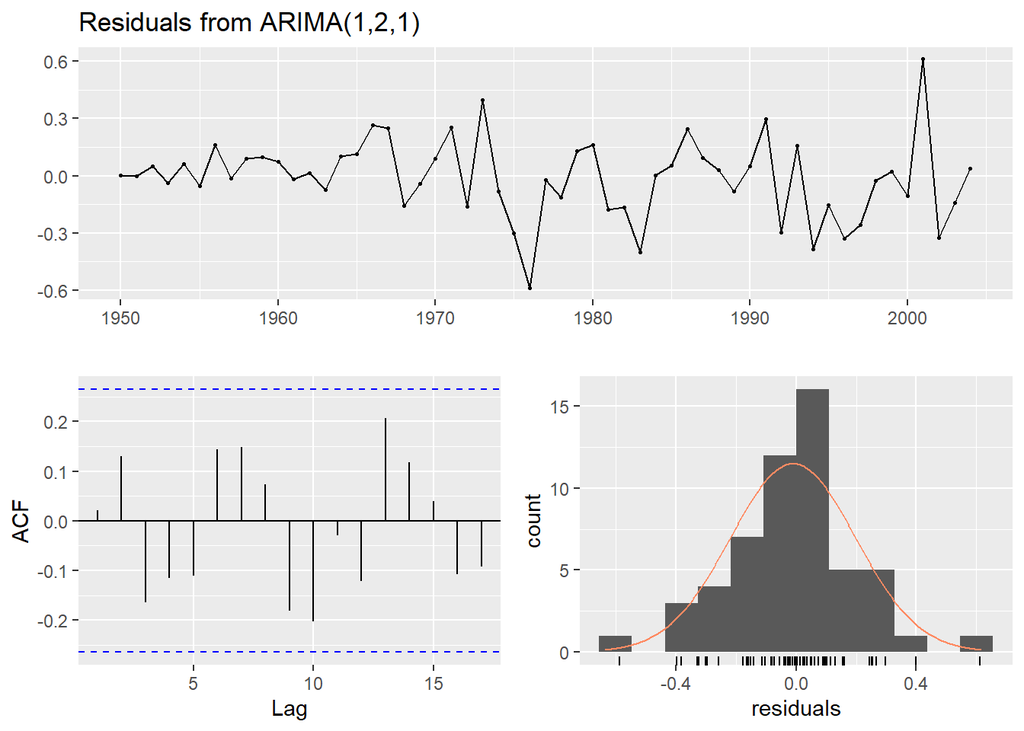

```
##
##  Ljung-Box test
##
## data:  Residuals from ARIMA(1,2,1)
## Q* = 12.419, df = 8, p-value = 0.1335
##
## Model df: 2.   Total lags used: 10
```

```r
checkresiduals(wm_fit)
```

This model is satisfactory because we see all autocorrelations within the blue lines showing that the residuals are acting like the white noise.

## e. Forecast three times ahead. Check your forecasts by hand to make sure that you know how they have been calculated.

```r
forecast(wm_fit, h=3)
```

```
##      Point Forecast    Lo 80    Hi 80    Lo 95    Hi 95
## 2005       2.470660 2.194836 2.746484 2.048824 2.892496
## 2006       2.363106 1.986351 2.739862 1.786908 2.939304
## 2007       2.252833 1.765391 2.740276 1.507354 2.998313
```

## f. Create a plot of the series with forecasts and prediction intervals for the next three periods shown.

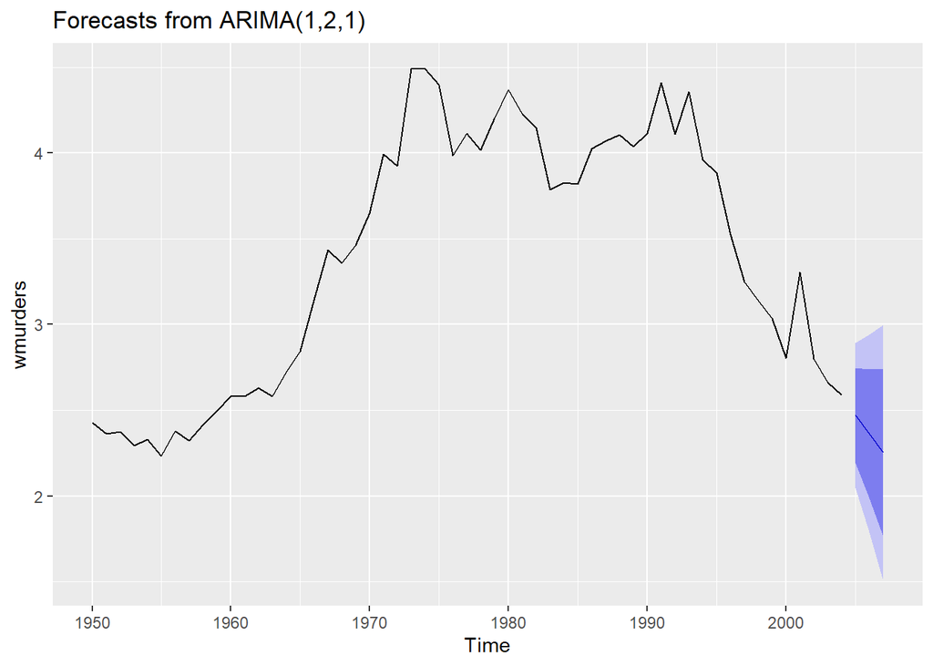

```r
autoplot(forecast(wm_fit, h=3), PI = T)
```

## g. Does auto.arima() give the same model you have chosen? If not, which model do you think is better?

```r
wm_fit2 <- auto.arima(wmurders)
summary(wm_fit2)
```

```
## Series: wmurders
## ARIMA(1,2,1)
##
## Coefficients:
##           ar1      ma1
##       -0.2434  -0.8261
## s.e.   0.1553   0.1143
##
## sigma^2 estimated as 0.04632:  log likelihood=6.44
## AIC=-6.88   AICc=-6.39   BIC=-0.97
##
## Training set error measures:
##                       ME      RMSE       MAE        MPE     MAPE      MASE
## Training set -0.01065956 0.2072523 0.1528734 -0.2149476 4.335214 0.9400996
##                    ACF1
## Training set 0.02176343
```

The `auto.arima()` function does give us the same model.